# Iris - Data Analyses, Visualization, Hypotheses

## Data Analyses

```python
# Packages loader

import seaborn as sns
import pandas
import matplotlib.pyplot as plt
```

```python
# List all the datasets within seaboarn

sns.get_dataset_names()
```

```
['anagrams',
 'anscombe',
 'attention',
 'brain_networks',
 'car_crashes',
 'diamonds',
 'dots',
 'dowjones',
 'exercise',
 'flights',
 'fmri',
 'geyser',
 'glue',
 'healthexp',
 'iris',
 'mpg',
 'penguins',
 'planets',
 'seaice',
 'taxis',
 'tips',
 'titanic']
```

```python
# Loading iris dataset

df_iris = sns.load_dataset('iris')
```

```python
# Displaying headers of dataset

df_iris.head()
```

|  | sepal_length | sepal_width | petal_length | petal_width | species |
| --- | --- | --- | --- | --- | --- |
| 0 | 5.1 | 3.5 | 1.4 | 0.2 | setosa |
| 1 | 4.9 | 3.0 | 1.4 | 0.2 | setosa |
| 2 | 4.7 | 3.2 | 1.3 | 0.2 | setosa |
| 3 | 4.6 | 3.1 | 1.5 | 0.2 | setosa |
| 4 | 5.0 | 3.6 | 1.4 | 0.2 | setosa |

```python
# Learning about the missing information, data-types, non-null row count

df_iris.info()
```

```
<class 'pandas.core.frame.DataFrame'>
RangeIndex: 150 entries, 0 to 149
Data columns (total 5 columns):
 #   Column        Non-Null Count  Dtype
---  ------        --------------  -----
 0   sepal_length  150 non-null    float64
 1   sepal_width   150 non-null    float64
 2   petal_length  150 non-null    float64
 3   petal_width   150 non-null    float64
 4   species       150 non-null    object
dtypes: float64(4), object(1)
memory usage: 6.0+ KB
```

```python
# Calculating descriptive statistics

print("Descriptive Statistics For Iris:\n")
df_iris.describe()
```

```
Descriptive Statistics For Iris:
```

|  | sepal_length | sepal_width | petal_length | petal_width |
| --- | --- | --- | --- | --- |
| count | 150.000000 | 150.000000 | 150.000000 | 150.000000 |
| mean | 5.843333 | 3.057333 | 3.758000 | 1.199333 |
| std | 0.828066 | 0.435866 | 1.765298 | 0.762238 |
| min | 4.300000 | 2.000000 | 1.000000 | 0.100000 |
| 25% | 5.100000 | 2.800000 | 1.600000 | 0.300000 |
| 50% | 5.800000 | 3.000000 | 4.350000 | 1.300000 |
| 75% | 6.400000 | 3.300000 | 5.100000 | 1.800000 |
| max | 7.900000 | 4.400000 | 6.900000 | 2.500000 |

```python
# Calculating statistics for categorical columns

print("Categorical Statistics For Iris:\n")
df_iris.describe(include=['object'])
```

```
Categorical Statistics For Iris:
```

|  | species |
| --- | --- |
| count | 150 |
| unique | 3 |
| top | setosa |
| freq | 50 |

```python
# Calculating statistics for all the columns

print("All Statistics For Iris:\n")
df_iris.describe(include='all')
```

```
All Statistics For Iris:
```

|  | sepal_length | sepal_width | petal_length | petal_width | species |
| --- | --- | --- | --- | --- | --- |
| count | 150.000000 | 150.000000 | 150.000000 | 150.000000 | 150 |
| unique | NaN | NaN | NaN | NaN | 3 |
| top | NaN | NaN | NaN | NaN | setosa |
| freq | NaN | NaN | NaN | NaN | 50 |
| mean | 5.843333 | 3.057333 | 3.758000 | 1.199333 | NaN |
| std | 0.828066 | 0.435866 | 1.765298 | 0.762238 | NaN |
| min | 4.300000 | 2.000000 | 1.000000 | 0.100000 | NaN |
| 25% | 5.100000 | 2.800000 | 1.600000 | 0.300000 | NaN |
| 50% | 5.800000 | 3.000000 | 4.350000 | 1.300000 | NaN |
| 75% | 6.400000 | 3.300000 | 5.100000 | 1.800000 | NaN |
| max | 7.900000 | 4.400000 | 6.900000 | 2.500000 | NaN |

## Visualization

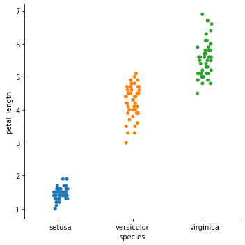

```python
# Catplot chart representing species against petal length

"""
https://seaborn.pydata.org/generated/seaborn.catplot.html

seaborn.catplot(data=None, *, x=None, y=None, hue=None, row=None, col=None, col_wrap=None, estimator='mean',\
                errorbar=('ci', 95), n_boot=1000, units=None, seed=None, order=None, hue_order=None, row_order=None,\
                col_order=None, height=5, aspect=1, kind='strip', native_scale=False, formatter=None, orient=None, color=None,\
                palette=None, hue_norm=None, legend='auto', legend_out=True, sharex=True, sharey=True, margin_titles=False,\
                facet_kws=None, ci='deprecated', **kwargs)
"""

catplot_chart = sns.catplot(x = "species", y = "petal_length", data = df_iris)
plt.show()
```

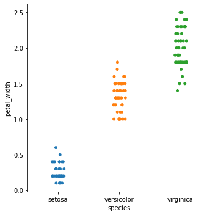

```python
# Catplot chart representing petal width against species

"""
https://seaborn.pydata.org/generated/seaborn.catplot.html

seaborn.catplot(data=None, *, x=None, y=None, hue=None, row=None, col=None, col_wrap=None, estimator='mean',\
                errorbar=('ci', 95), n_boot=1000, units=None, seed=None, order=None, hue_order=None, row_order=None,\
                col_order=None, height=5, aspect=1, kind='strip', native_scale=False, formatter=None, orient=None, color=None,\
                palette=None, hue_norm=None, legend='auto', legend_out=True, sharex=True, sharey=True, margin_titles=False,\
                facet_kws=None, ci='deprecated', **kwargs)
"""

catplot_chart = sns.catplot(x = "species", y = "petal_width", data = df_iris)
plt.show()
```

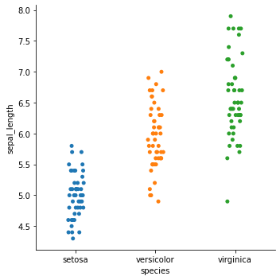

```python
# Catplot chart representing sepal length against species

"""
https://seaborn.pydata.org/generated/seaborn.catplot.html

seaborn.catplot(data=None, *, x=None, y=None, hue=None, row=None, col=None, col_wrap=None, estimator='mean',\
                errorbar=('ci', 95), n_boot=1000, units=None, seed=None, order=None, hue_order=None, row_order=None,\
                col_order=None, height=5, aspect=1, kind='strip', native_scale=False, formatter=None, orient=None, color=None,\
                palette=None, hue_norm=None, legend='auto', legend_out=True, sharex=True, sharey=True, margin_titles=False,\
                facet_kws=None, ci='deprecated', **kwargs)
"""

catplot_chart = sns.catplot(x = "species", y = "sepal_length", data = df_iris)
plt.show()
```

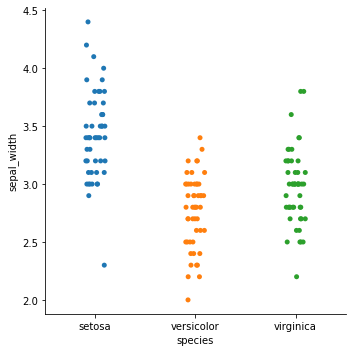

```python
# Catplot chart representing sepal width against species

"""
https://seaborn.pydata.org/generated/seaborn.catplot.html

seaborn.catplot(data=None, *, x=None, y=None, hue=None, row=None, col=None, col_wrap=None, estimator='mean',\
                errorbar=('ci', 95), n_boot=1000, units=None, seed=None, order=None, hue_order=None, row_order=None,\
                col_order=None, height=5, aspect=1, kind='strip', native_scale=False, formatter=None, orient=None, color=None,\
                palette=None, hue_norm=None, legend='auto', legend_out=True, sharex=True, sharey=True, margin_titles=False,\
                facet_kws=None, ci='deprecated', **kwargs)
"""

catplot_chart = sns.catplot(x = "species", y = "sepal_width", data = df_iris)
plt.show()
```

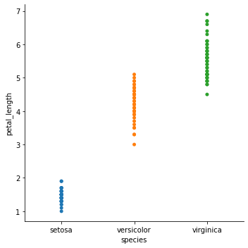

```python
# Catplot chart representing petal length against species by removing jitter

"""
https://seaborn.pydata.org/generated/seaborn.catplot.html

seaborn.catplot(data=None, *, x=None, y=None, hue=None, row=None, col=None, col_wrap=None, estimator='mean',\
                errorbar=('ci', 95), n_boot=1000, units=None, seed=None, order=None, hue_order=None, row_order=None,\
                col_order=None, height=5, aspect=1, kind='strip', native_scale=False, formatter=None, orient=None, color=None,\
                palette=None, hue_norm=None, legend='auto', legend_out=True, sharex=True, sharey=True, margin_titles=False,\
                facet_kws=None, ci='deprecated', **kwargs)

The jitter parameter controls the magnitude of jitter or disables it altogether. jitter can be used to provide displacements\
along the horizontal axis, which is useful when there are large clusters of data points.

"""

catplot_chart_withoutJitter = sns.catplot(x = "species", y = "petal_length", data = df_iris, jitter=False)
plt.show()
```

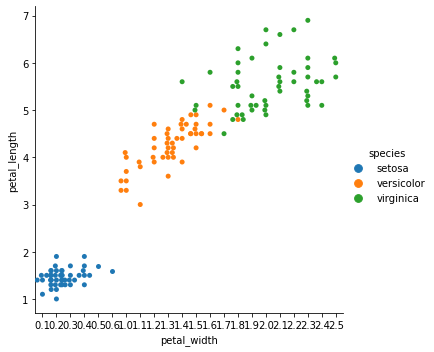

```python
# Catplot chart representing petal width to petal length defining hue as species

"""
https://seaborn.pydata.org/generated/seaborn.catplot.html

seaborn.catplot(data=None, *, x=None, y=None, hue=None, row=None, col=None, col_wrap=None, estimator='mean',\
                errorbar=('ci', 95), n_boot=1000, units=None, seed=None, order=None, hue_order=None, row_order=None,\
                col_order=None, height=5, aspect=1, kind='strip', native_scale=False, formatter=None, orient=None, color=None,\
                palette=None, hue_norm=None, legend='auto', legend_out=True, sharex=True, sharey=True, margin_titles=False,\
                facet_kws=None, ci='deprecated', **kwargs)

The jitter parameter controls the magnitude of jitter or disables it altogether. jitter can be used to provide displacements\
along the horizontal axis, which is useful when there are large clusters of data points.

"""

catplot_chart_HueSwarm = sns.catplot(x = "petal_width", y = "petal_length", data = df_iris, hue="species", kind="swarm")
plt.show()
```

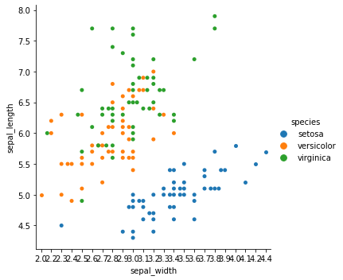

```python
# Catplot chart representing sepal width to sepal length defining hue as species

"""
https://seaborn.pydata.org/generated/seaborn.catplot.html

seaborn.catplot(data=None, *, x=None, y=None, hue=None, row=None, col=None, col_wrap=None, estimator='mean',\
                errorbar=('ci', 95), n_boot=1000, units=None, seed=None, order=None, hue_order=None, row_order=None,\
                col_order=None, height=5, aspect=1, kind='strip', native_scale=False, formatter=None, orient=None, color=None,\
                palette=None, hue_norm=None, legend='auto', legend_out=True, sharex=True, sharey=True, margin_titles=False,\
                facet_kws=None, ci='deprecated', **kwargs)

The jitter parameter controls the magnitude of jitter or disables it altogether. jitter can be used to provide displacements\
along the horizontal axis, which is useful when there are large clusters of data points.

"""

catplot_chart_HueSwarm = sns.catplot(x = "sepal_width", y = "sepal_length", data = df_iris, hue="species", kind="swarm")
plt.show()
```

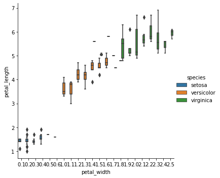

```python
# Catplot chart representing petal width to petal length defining hue as species, kind as box

"""
https://seaborn.pydata.org/generated/seaborn.catplot.html

seaborn.catplot(data=None, *, x=None, y=None, hue=None, row=None, col=None, col_wrap=None, estimator='mean',\
                errorbar=('ci', 95), n_boot=1000, units=None, seed=None, order=None, hue_order=None, row_order=None,\
                col_order=None, height=5, aspect=1, kind='strip', native_scale=False, formatter=None, orient=None, color=None,\
                palette=None, hue_norm=None, legend='auto', legend_out=True, sharex=True, sharey=True, margin_titles=False,\
                facet_kws=None, ci='deprecated', **kwargs)

The jitter parameter controls the magnitude of jitter or disables it altogether. jitter can be used to provide displacements\
along the horizontal axis, which is useful when there are large clusters of data points.

"""

catplot_chart_HueBox = sns.catplot(x = "petal_width", y = "petal_length", data = df_iris, hue="species", kind="box")
plt.show()
```

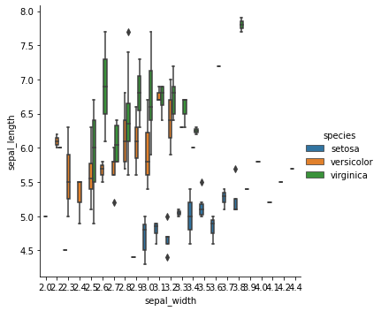

```python
# Catplot chart representing sepal width to sepal length defining hue as species, kind as box

"""
https://seaborn.pydata.org/generated/seaborn.catplot.html

seaborn.catplot(data=None, *, x=None, y=None, hue=None, row=None, col=None, col_wrap=None, estimator='mean',\
                errorbar=('ci', 95), n_boot=1000, units=None, seed=None, order=None, hue_order=None, row_order=None,\
                col_order=None, height=5, aspect=1, kind='strip', native_scale=False, formatter=None, orient=None, color=None,\
                palette=None, hue_norm=None, legend='auto', legend_out=True, sharex=True, sharey=True, margin_titles=False,\
                facet_kws=None, ci='deprecated', **kwargs)

The jitter parameter controls the magnitude of jitter or disables it altogether. jitter can be used to provide displacements\
along the horizontal axis, which is useful when there are large clusters of data points.
"""

catplot_chart_HueBox = sns.catplot(x = "sepal_width", y = "sepal_length", data = df_iris, hue="species", kind="box")
plt.show()
```

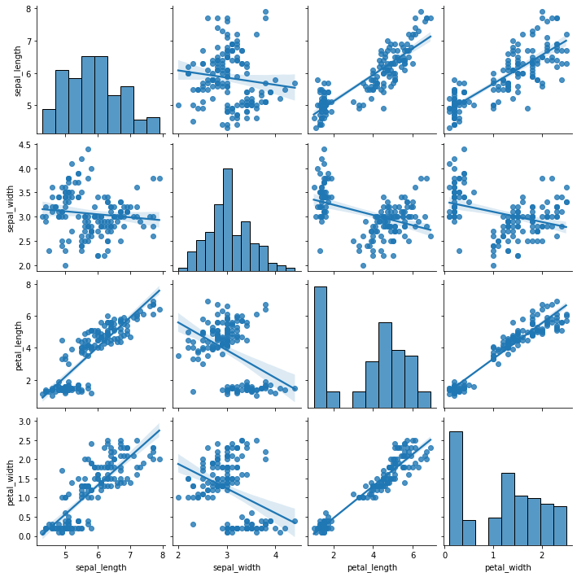

```python
# Pairplotting all the columns of the iris dataset

"""
https://seaborn.pydata.org/generated/seaborn.pairplot.html

seaborn.pairplot(data, *, hue=None, hue_order=None, palette=None, vars=None, x_vars=None, y_vars=None, kind='scatter',\
                 diag_kind='auto', markers=None, height=2.5, aspect=1, corner=False, dropna=False, plot_kws=None,\
                 diag_kws=None, grid_kws=None, size=None)
"""

sns.pairplot(df_iris, kind="reg")
```

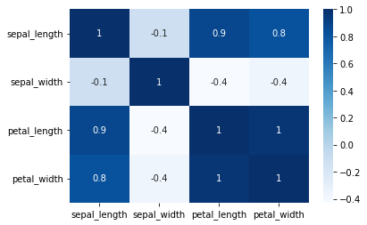

```python
# Correlation heatmap for all the columns of the iris dataset

"""
https://seaborn.pydata.org/generated/seaborn.heatmap.html

seaborn.heatmap(data, *, vmin=None, vmax=None, cmap=None, center=None, robust=False, annot=None, fmt='.2g', annot_kws=None,\
                linewidths=0, linecolor='white', cbar=True, cbar_kws=None, cbar_ax=None, square=False, xticklabels='auto',\
                yticklabels='auto', mask=None, ax=None, **kwargs)
"""

heatmap = sns.heatmap(df_iris.corr(), annot=True, cmap="Blues", fmt='.1g')
```

## Hypotheses

#### Hypothesis - The average sepal length of all iris flowers is greater than 5.

#### Data

```python
# To test this hypothesis, we can calculate the mean sepal length and compare it to 5.

mean_sepal_length = df_iris['sepal_length'].mean()
print(mean_sepal_length > 5)
```

```
True
```

#### Conclusion - Since, the mean sepal length is greater than 5, we accept the above stated hypothesis.

#### ---------------------------------------------------------------------------------------------------------

#### Hypothesis - The average petal width of all iris flowers is less than 1.2.

#### Data

```python
# To test this hypothesis, we can calculate the mean petal width and compare it to 1.2.

mean_petal_width = df_iris['petal_width'].mean()
print(mean_petal_width < 1.2)
```

```
True
```

#### Conclusion - Since, the mean petal width is less than 1.2, we accept the above stated hypothesis.

#### ---------------------------------------------------------------------------------------------------------

#### Hypothesis - The standard deviation of sepal width for virginica species is less than that of setosa species.

#### Data

```python
# To test this hypothesis, we can calculate the standard deviation of sepal width for each species and compare them.

std_sepal_width_virginica = df_iris[df_iris['species'] == 'virginica']['sepal_width'].std()
std_sepal_width_setosa = df_iris[df_iris['species'] == 'setosa']['sepal_width'].std()
print(std_sepal_width_virginica < std_sepal_width_setosa)
```

```
True
```

#### Conclusion - Since the standard deviation of sepal width for virginica species is less than that of setosa species, we accept the above stated hypothesis.

#### ---------------------------------------------------------------------------------------------------------

#### Hypothesis - The median petal length of versicolor species is equal to the median petal length of virginica species.

#### Data

```python
# To test this hypothesis, we can calculate the median petal length for each species and compare them.

median_petal_length_versicolor = df_iris[df_iris['species'] == 'versicolor']['petal_length'].median()
median_petal_length_virginica = df_iris[df_iris['species'] == 'virginica']['petal_length'].median()
print(median_petal_length_versicolor == median_petal_length_virginica)
```

```
False
```

#### Conclusion - Since the median petal length of versicolor species is different from the median petal length of virginica species, we reject the above stated hypothesis.

#### ---------------------------------------------------------------------------------------------------------

#### Hypothesis - The maximum sepal length among all species is lesser than or equal to 7.

#### Data

```python
# To test this hypothesis, we can find the maximum sepal length and compare it to 7.

max_sepal_length = df_iris['sepal_length'].max()
print(max_sepal_length <= 7)
```

```
False
```

#### Conclusion - Since the maximum sepal length among atleast one species is greater than 7, we reject the above stated hypothesis.

#### ---------------------------------------------------------------------------------------------------------

#### Hypothesis - The 75th percentile of petal width for setosa species is greater than the 75th percentile of petal width for versicolor species.

#### Data

```python
# To test this hypothesis, we can calculate the 75th percentile of petal width for each species and compare them.

percentile_75_setosa = df_iris[df_iris['species'] == 'setosa']['petal_width'].quantile(0.75)
percentile_75_versicolor = df_iris[df_iris['species'] == 'versicolor']['petal_width'].quantile(0.75)
print(percentile_75_setosa > percentile_75_versicolor)
```

```
False
```

#### ---------------------------------------------------------------------------------------------------------

#### Hypothesis - The range of sepal width for virginica species is bigger than that of versicolor species.

#### Data

```python
# To test this hypothesis, we can calculate the range of sepal width for each species and compare them.

range_sepal_width_virginica = df_iris[df_iris['species'] == 'virginica']['sepal_width'].max() - \
df_iris[df_iris['species'] == 'virginica']['sepal_width'].min()
range_sepal_width_versicolor = df_iris[df_iris['species'] == 'versicolor']['sepal_width'].max() - \
df_iris[df_iris['species'] == 'versicolor']['sepal_width'].min()
print(range_sepal_width_virginica > range_sepal_width_versicolor)
```

```
True
```

#### Conclusion - Since the range of sepal width for virginica species is bigger than that of versicolor species, we accept the above stated hypothesis.

#### ---------------------------------------------------------------------------------------------------------

#### Hypothesis - The mean sepal length for setosa species is significantly different from the mean sepal length for virginica species.

#### Data

```python
# To test this hypothesis, we can perform a t-test between the mean sepal length of the setosa species and \
# the mean sepal length of the virginica species.

import scipy.stats as stats

setosa_sepal_length = df_iris[df_iris['species'] == 'setosa']['sepal_length']
virginica_sepal_length = df_iris[df_iris['species'] == 'virginica']['sepal_length']

t_statistic, p_value = stats.ttest_ind(setosa_sepal_length, virginica_sepal_length)
print(p_value < 0.05)
```

```
True
```

#### ---------------------------------------------------------------------------------------------------------